# Crime DC

# Reading in the data

The first thing to do is to read in the data from the csv file.

```r
library(readr)
library(dplyr)
```

```r
library(ggplot2)
library(DT)
library(ggrepel)
library(leaflet)
library(leaflet.extras)
library(janitor)
library(MASS)
library(scales)
library(ggmap)
library(tidyverse)
library(lubridate)
setwd("C:/Users/Jeffo/Downloads")
crimedc<- read.csv('crimedc.csv') #read in from csv file
```

# Cleaning the data

```r
crimedc <- crimedc%>%
  clean_names()
crimedc$ccn <- NULL
```

## Convert all titles into lowercase for easier reading

```r
proper_case <- function(x) {
  return (gsub("\\b([A-Z])([A-Z]+)", "\\U\\1\\L\\2" , x, perl=TRUE))
}
 crimedc<- crimedc%>% mutate(block = proper_case(block))
```

## Using mutate and lubricate to separate date and time

```r
 #using the mutate function, create separate variables for each month, year and day
  crimedc<-crimedc%>%
    mutate(
      incident_hour=hour(ymd_hms(report_dat)),
      incident_month=month(ymd_hms(report_dat)),
     incident_year=year(ymd_hms(report_dat)),
      atnight=incident_hour>6 & incident_hour<18,
     burglary=offense==( 'BURGLARY')
    )
```

```r
dcburglary<-filter(crimedc, burglary==TRUE)
dcatnight<-filter(crimedc, atnight==TRUE)
nightburglary<-filter(dcatnight, burglary==TRUE)
```

# Exploratory Data Anaylsis

There are 29 different variables in this dataset, as well as 26264 different observations. Most of the data variables are factor, and some are numerical variables.

```r
str(crimedc)
```

```
## 'data.frame':    26264 obs. of  29 variables:
##  $ i_x                 : num  -77 -77 -77 -77 -77.1 ...
##  $ y                   : num  38.9 38.9 38.9 38.9 38.9 ...
##  $ report_dat          : Factor w/ 26222 levels "2019-01-01T00:00:00.000Z",..: 24795 25139 24393 24955 24993 25193 25460 25462 25513 25337 ...
##  $ shift               : Factor w/ 3 levels "DAY","EVENING",..: 1 2 1 3 1 1 1 1 2 2 ...
##  $ method              : Factor w/ 3 levels "GUN","KNIFE",..: 3 3 3 3 3 3 3 3 3 3 ...
##  $ offense             : Factor w/ 9 levels "ARSON","ASSAULT W/DANGEROUS WEAPON",..: 9 9 9 8 8 9 9 9 9 8 ...
##  $ block               : chr  "700  - 799 Block Of Upshur Street Nw" "1650 - 1691 Block Of Lanier Place Nw" "700 - 799 Block Of 7TH Street Nw" "1100 - 1199 Block Of Park Street Ne" ...
##  $ xblock              : num  398050 396582 398098 400790 392391 ...
##  $ yblock              : num  141562 139810 136808 136106 141648 ...
##  $ ward                : int  4 1 2 6 3 1 1 4 6 3 ...
##  $ anc                 : Factor w/ 40 levels "1A","1B","1C",..: 19 3 7 26 14 3 3 20 28 14 ...
##  $ district            : int  NA NA NA NA NA NA NA NA NA NA ...
##  $ psa                 : int  NA NA NA NA NA NA NA NA NA NA ...
##  $ neighborhood_cluster: Factor w/ 40 levels "","Cluster 1",..: 11 2 39 19 4 2 2 11 19 4 ...
##  $ block_group         : Factor w/ 451 levels "","000100 1",..: 120 168 224 324 46 176 173 109 329 46 ...
##  $ census_tract        : int  2400 3900 5800 8100 1001 4002 4001 2201 8301 1001 ...
##  $ voting_precinct     : Factor w/ 143 levels "Precinct 1","Precinct 10",..: 84 73 34 128 68 62 62 95 127 68 ...
##  $ latitude            : num  38.9 38.9 38.9 38.9 38.9 ...
##  $ longitude           : num  -77 -77 -77 -77 -77.1 ...
##  $ bid                 : Factor w/ 12 levels "","ADAMS MORGAN",..: 1 1 6 1 1 1 1 1 1 1 ...
##  $ start_date          : Factor w/ 26190 levels "2005-04-17T15:00:34.000Z",..: 24812 25071 24459 24923 25031 25059 25473 23790 25496 24916 ...
##  $ end_date            : Factor w/ 22330 levels "","2005-04-17T15:30:31.000Z",..: 21071 21350 20755 21171 21267 21423 21678 20379 21731 21176 ...
##  $ objectid            : int  352778328 352778329 352778330 352778331 352778332 352778333 352778334 352778335 352778336 352778337 ...
##  $ octo_record_id      : Factor w/ 26264 levels "17084415-01",..: 26250 26251 26252 26253 26254 26255 26256 26257 26258 26259 ...
##  $ incident_hour       : int  12 21 13 0 12 14 10 10 19 22 ...
##  $ incident_month      : num  10 10 9 10 10 10 10 10 10 10 ...
##  $ incident_year       : num  2019 2019 2019 2019 2019 ...
##  $ atnight             : logi  TRUE FALSE TRUE FALSE TRUE TRUE ...
##  $ burglary            : logi  FALSE FALSE FALSE FALSE FALSE FALSE ...
```

## Looking at different Offenses in the dataset

In this dataset, there are 9 unique offenses that are represented in the datset.Unfortunately, drugs is not represented in this dataset, so we will focus on burglary.

```r
unique(crimedc$offense)
```

```
## [1] THEFT/OTHER                THEFT F/AUTO
## [3] SEX ABUSE                  HOMICIDE
## [5] ASSAULT W/DANGEROUS WEAPON ROBBERY
## [7] BURGLARY                   MOTOR VEHICLE THEFT
## [9] ARSON
## 9 Levels: ARSON ASSAULT W/DANGEROUS WEAPON BURGLARY ... THEFT/OTHER
```

## Looking at Missing values

As you can see, there are no missing offense observations, which will make this dataset as accurate as possible.

```r
sum(is.na(crimedc$offense))
```

```
## [1] 0
```

## Tally by Offense

The crime I will mainly be focusing on in this dataset is burglary. As we can see, there are 1015 different observations for Burglary arrests.

```r
table(crimedc$offense)[order(table(crimedc$offense), decreasing = T)] # Order decreasing
```

```
##
##                THEFT/OTHER               THEFT F/AUTO
##                      11934                       8208
##        MOTOR VEHICLE THEFT                    ROBBERY
##                       1783                       1738
## ASSAULT W/DANGEROUS WEAPON                   BURGLARY
##                       1277                       1015
##                  SEX ABUSE                   HOMICIDE
##                        166                        136
##                      ARSON
##                          7
```

## Looking at Frequency of Months

Next I have a look at the frequency of crimes by month. Looking at our results, you can see that the most popular months for dc crimes are August and September.

```r
group_by(.data = crimedc, incident_month) %>%
filter(!is.na(incident_month))%>%
    summarise(count = n()) %>%
    arrange(desc(count))
```

```
## # A tibble: 10 x 2
##    incident_month count
##             <dbl> <int>
##  1              8  3060
##  2              9  3033
##  3              7  3018
##  4              6  2863
##  5              1  2720
##  6              5  2717
##  7              4  2558
##  8              3  2438
##  9              2  2303
## 10             10  1554
```

## Looking at Frequency of Months for Burglary

Next I have a look at the frequency of burglary crimes by month. Looking at our results, you can see that the most popular months for dc burglary crimes are May and Janauary. Surprsingly, August is still in the top 3.Something interesting to note is that November and December there is no data.

```r
group_by(.data = dcburglary, incident_month) %>%
filter(!is.na(incident_month))%>%
    summarise(count = n()) %>%
    arrange(desc(count))
```

```
## # A tibble: 10 x 2
##    incident_month count
##             <dbl> <int>
##  1              5   126
##  2              1   125
##  3              8   110
##  4              2   107
##  5              6   107
##  6              9   106
##  7              3   101
##  8              7    97
##  9              4    87
## 10             10    49
```

# Visualizations

## DC arrests by ward

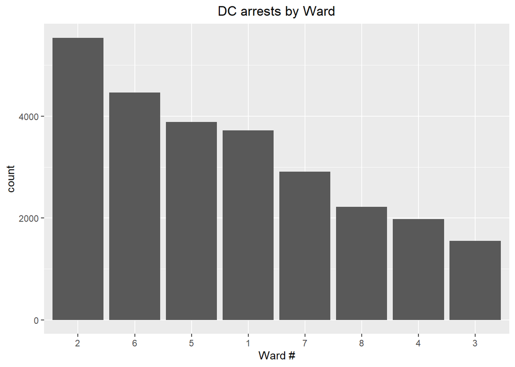

```r
ggplot(data=crimedc,aes(x=reorder(ward,ward,function(x)-length(x))))+geom_bar()+labs(title="DC arrests by Ward", x="Ward #")+ theme(plot.title = element_text(hjust = 0.5))
```

## Arrests in DC by Month

For DC, there is a steady increase in arrests from Feburary till September, with its peak at August.

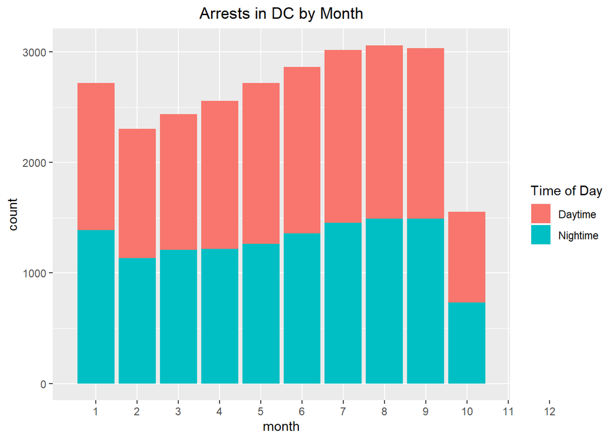

```r
ggplot(data=crimedc, aes(x=incident_month))+geom_bar(aes(fill=atnight))+labs(title="Arrests in DC by Month")+ theme(plot.title = element_text(hjust = 0.5))+scale_x_discrete(name ="month",
                    limits=c("1","2","3","4","5","6","7","8","9","10","11", "12"))+scale_fill_discrete(name = "Time of Day", labels = c("Daytime", "Nightime"))
```

## Burglary Arrests in DC by Month

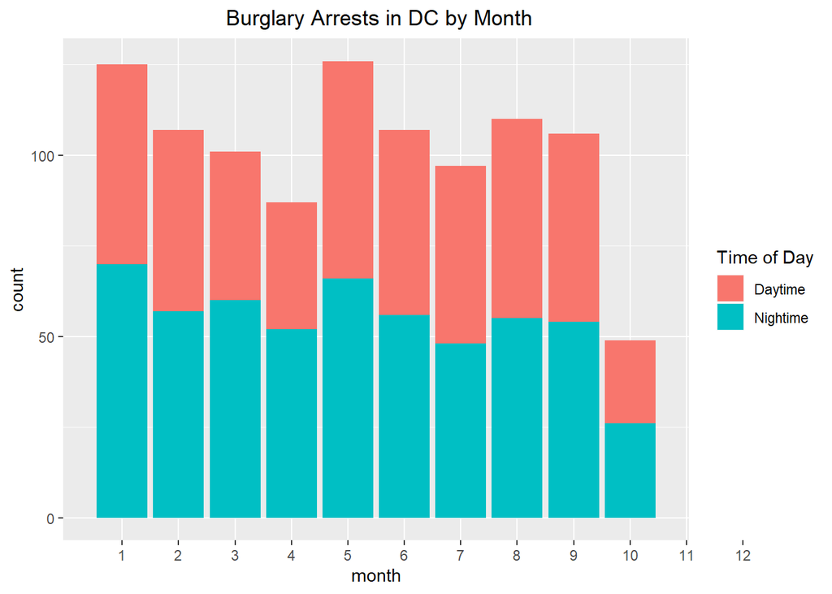

```r
ggplot(data=dcburglary, aes(x=incident_month))+geom_bar(aes(fill=atnight))+labs(title=" Burglary Arrests in DC by Month")+ theme(plot.title = element_text(hjust = 0.5))+scale_x_discrete(name ="month",
                    limits=c("1","2","3","4","5","6","7","8","9","10","11", "12"))+scale_fill_discrete(name = "Time of Day", labels = c("Daytime", "Nightime"))
```

## DC arrests at night vs daytime

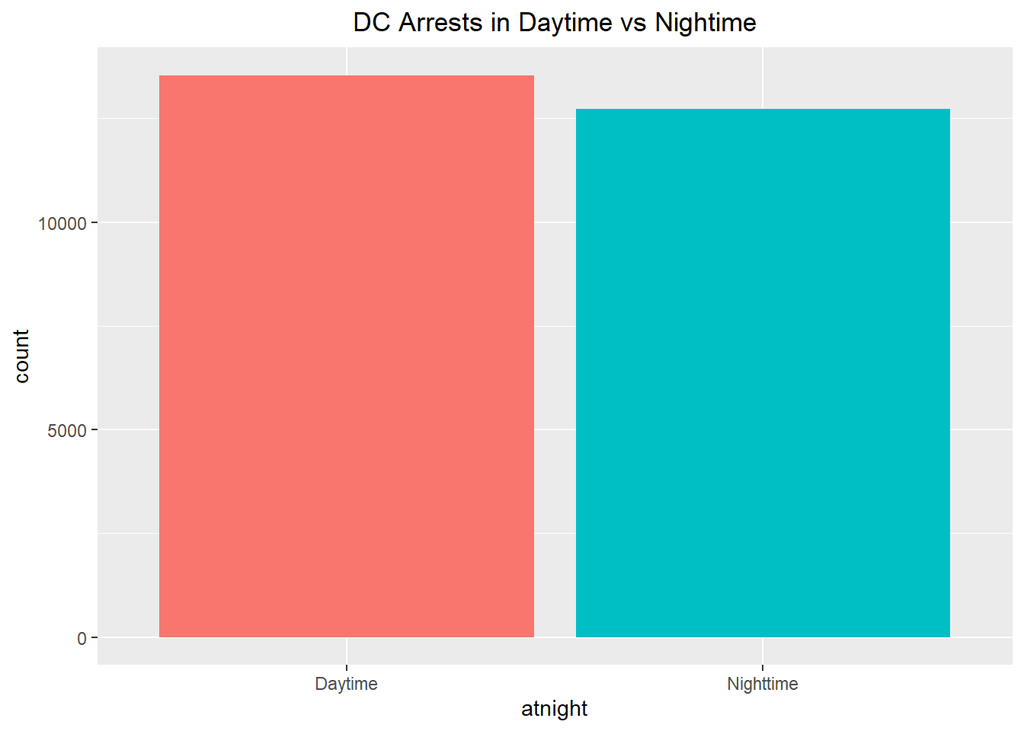

```r
P<-ggplot(data=subset(crimedc, !is.na(atnight)), aes(x=atnight)) + geom_bar(aes(fill=atnight))
P+scale_x_discrete(labels=c("FALSE" = "Daytime","TRUE" = "Nighttime"))+labs(title="DC Arrests in Daytime vs Nightime")+ theme(plot.title = element_text(hjust = 0.5))+scale_fill_discrete(name = "Time of Day", labels = c("Daytime", "Nightime"))+theme(legend.position = "none")
```

## DC burglary arrests daytime vs nightime

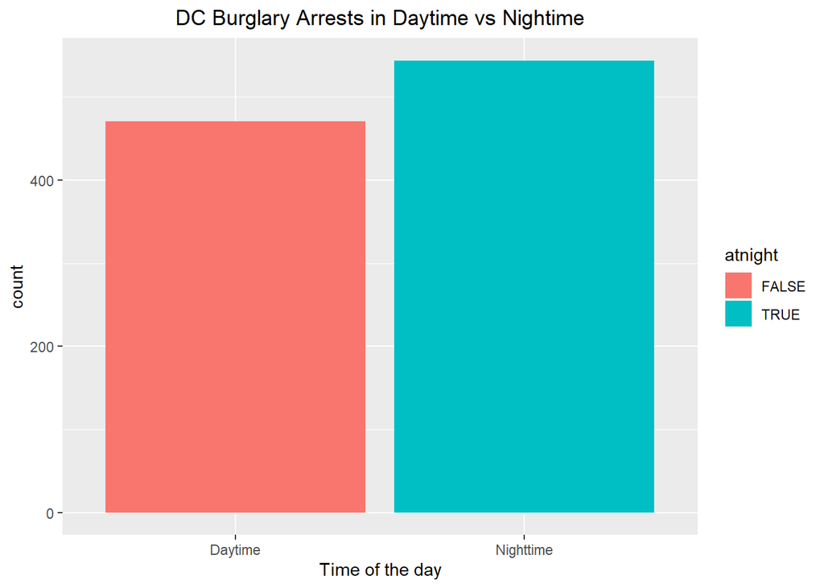

```r
P<-ggplot(data=subset(dcburglary, !is.na(atnight)), aes(x=atnight)) + geom_bar(aes(fill=atnight))
P+scale_x_discrete(labels=c("FALSE" = "Daytime","TRUE" = "Nighttime"))+labs(title="DC Burglary Arrests in Daytime vs Nightime", x="Time of the day")+ theme(plot.title = element_text(hjust = 0.5))
```

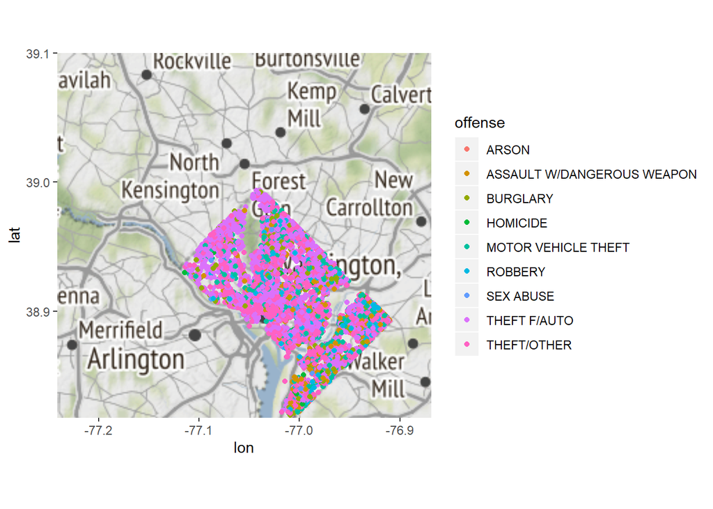

```r
#using the stamen mapping, create boundaries for the map
dc_bb <- c(left = -77.2413345,
           bottom = 38.8171923,
           right = -76.868707,
           top = 39.1)
#get map outline
dc_stamen <- get_stamenmap(bbox = dc_bb,
                           zoom = 10)
#using ggmaps, create a map with the crimedc data
ggmap(dc_stamen)+ geom_point(data=crimedc, mapping = aes(x = longitude,
                                                          y = latitude, color=offense))
```

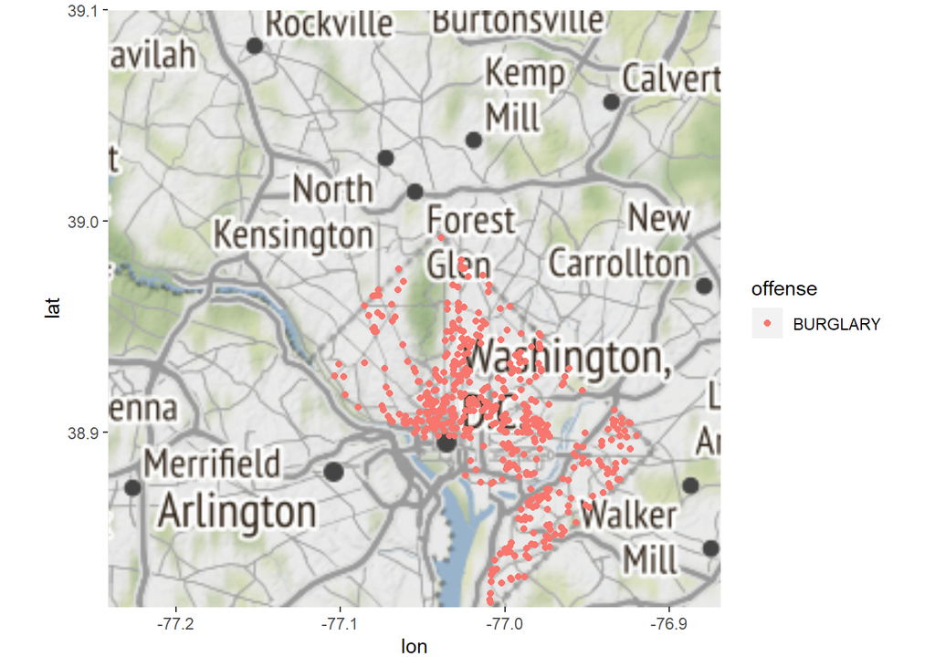

```r
ggmap(dc_stamen)+ geom_point(data=nightburglary, mapping = aes(x = longitude,
                                                          y = latitude, color=offense))
```

## Create a heat map for crimes in DC

```r
leaflet(crimedc) %>% addProviderTiles(providers$CartoDB.Positron) %>%
  addWebGLHeatmap(lng=~longitude, lat=~latitude, size = 200)
```

[interactive chart not shown]